# briana-sealey-ADA-data-reanalysis-assignment

#### Replicating binomial generalized linear mixed-effect models

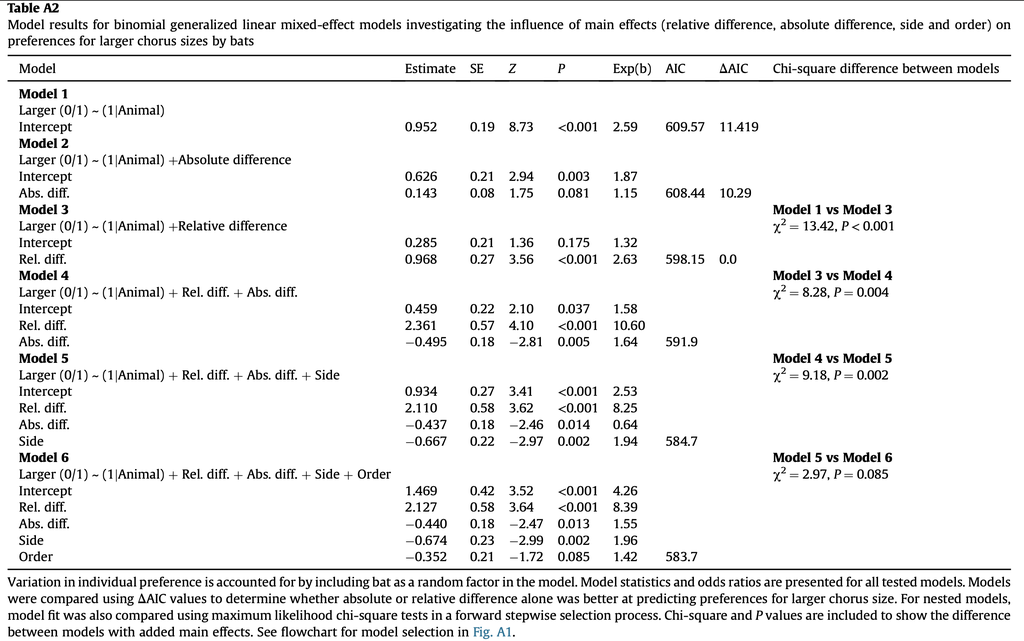

Table A2. Summary of binomial models & tests for their influence.

```r
colnames(data) #for generating different models
```

```
##  [1] "Animal"    "Order"     "Treatment" "Choice"    "Larger"    "LoR"
##  [7] "Reward"    "Latency"   "AbsDiff"   "Ratio"     "RelDiff"
```

```r
#Larger (0/1) ~ (1 | Animal)
m1 <- glmer(data$Larger ~ (1 | data$Animal), data = data, family = binomial)

#Larger (0/1) ~ (1 | Animal) + Absolute Difference
m2 <- glmer(data$Larger ~ (1 | data$Animal) + data$AbsDiff, data = data, family = binomial)

#Larger (0/1) ~ (1 | Animal) + Relative Difference
m3 <- glmer(data$Larger ~ (1 | data$Animal) + data$RelDiff, data = data, family = binomial)

#Larger (0/1) ~ (1 | Animal) + Rel diff + Abs diff
m4 <- glmer(data$Larger ~ (1 | data$Animal) + data$RelDiff + data$AbsDiff, data = data, family = binomial)

#Larger (0/1) ~ (1 | Animal) + Rel diff + Abs diff + Side (LoR = Left or Right, testing for side biases)
m5 <- glmer(data$Larger ~ (1 | data$Animal) + data$RelDiff + data$AbsDiff + data$LoR, data = data, family = binomial)

#Larger (0/1) ~ (1 | Animal) + Rel diff + Abs diff + Side + Order
m6 <- glmer(data$Larger ~ (1 | data$Animal) + data$RelDiff + data$AbsDiff + data$LoR + data$Order, data = data, family = binomial)

#Summary for each model, here you can see that the estimates I calculated match up to those found in the table
summary(m1)
```

```
## Generalized linear mixed model fit by maximum likelihood (Laplace
##   Approximation) [glmerMod]
##  Family: binomial  ( logit )
## Formula: data$Larger ~ (1 | data$Animal)
##    Data: data
##
##      AIC      BIC   logLik deviance df.resid
##    609.6    618.0   -302.8    605.6      509
##
## Scaled residuals:
##     Min      1Q  Median      3Q     Max
## -1.7065 -1.5037  0.6101  0.6266  0.6785
##
## Random effects:
##  Groups      Name        Variance Std.Dev.
##  data$Animal (Intercept) 0.03182  0.1784
## Number of obs: 511, groups:  data$Animal, 17
##
## Fixed effects:
##             Estimate Std. Error z value Pr(>|z|)
## (Intercept)   0.9522     0.1089   8.744   <2e-16 ***
## ---
## Signif. codes:  0 '***' 0.001 '**' 0.01 '*' 0.05 '.' 0.1 ' ' 1
```

```r
summary(m2)
```

```
## Generalized linear mixed model fit by maximum likelihood (Laplace
##   Approximation) [glmerMod]
##  Family: binomial  ( logit )
## Formula: data$Larger ~ (1 | data$Animal) + data$AbsDiff
##    Data: data
##
##      AIC      BIC   logLik deviance df.resid
##    608.4    621.2   -301.2    602.4      508
##
## Scaled residuals:
##     Min      1Q  Median      3Q     Max
## -1.9910 -1.4357  0.5874  0.6410  0.7460
##
## Random effects:
##  Groups      Name        Variance Std.Dev.
##  data$Animal (Intercept) 0.03313  0.182
## Number of obs: 511, groups:  data$Animal, 17
##
## Fixed effects:
##              Estimate Std. Error z value Pr(>|z|)
## (Intercept)   0.62584    0.21289   2.940  0.00329 **
## data$AbsDiff  0.14279    0.08171   1.748  0.08053 .
## ---
## Signif. codes:  0 '***' 0.001 '**' 0.01 '*' 0.05 '.' 0.1 ' ' 1
##
## Correlation of Fixed Effects:
##             (Intr)
## data$AbsDff -0.858
```

```r
summary(m3)
```

```
## Generalized linear mixed model fit by maximum likelihood (Laplace
##   Approximation) [glmerMod]
##  Family: binomial  ( logit )
## Formula: data$Larger ~ (1 | data$Animal) + data$RelDiff
##    Data: data
##
##      AIC      BIC   logLik deviance df.resid
##    598.2    610.9   -296.1    592.2      508
##
## Scaled residuals:
##     Min      1Q  Median      3Q     Max
## -2.3529 -1.2667  0.5315  0.6675  0.8762
##
## Random effects:
##  Groups      Name        Variance Std.Dev.
##  data$Animal (Intercept) 0.03798  0.1949
## Number of obs: 511, groups:  data$Animal, 17
##
## Fixed effects:
##              Estimate Std. Error z value Pr(>|z|)
## (Intercept)    0.2853     0.2102   1.358 0.174592
## data$RelDiff   0.9678     0.2713   3.567 0.000361 ***
## ---
## Signif. codes:  0 '***' 0.001 '**' 0.01 '*' 0.05 '.' 0.1 ' ' 1
##
## Correlation of Fixed Effects:
##             (Intr)
## data$RelDff -0.847
```

```r
summary(m4)
```

```
## Generalized linear mixed model fit by maximum likelihood (Laplace
##   Approximation) [glmerMod]
##  Family: binomial  ( logit )
## Formula: data$Larger ~ (1 | data$Animal) + data$RelDiff + data$AbsDiff
##    Data: data
##
##      AIC      BIC   logLik deviance df.resid
##    591.9    608.8   -291.9    583.9      507
##
## Scaled residuals:
##     Min      1Q  Median      3Q     Max
## -2.5532 -1.2164  0.4706  0.6755  0.9103
##
## Random effects:
##  Groups      Name        Variance Std.Dev.
##  data$Animal (Intercept) 0.04223  0.2055
## Number of obs: 511, groups:  data$Animal, 17
##
## Fixed effects:
##              Estimate Std. Error z value Pr(>|z|)
## (Intercept)    0.4585     0.2190   2.093  0.03632 *
## data$RelDiff   2.3602     0.5752   4.103 4.07e-05 ***
## data$AbsDiff  -0.4949     0.1762  -2.808  0.00498 **
## ---
## Signif. codes:  0 '***' 0.001 '**' 0.01 '*' 0.05 '.' 0.1 ' ' 1
##
## Correlation of Fixed Effects:
##             (Intr) dt$RlD
## data$RelDff -0.131
## data$AbsDff -0.281 -0.883
```

```r
summary(m5)
```

```
## Generalized linear mixed model fit by maximum likelihood (Laplace
##   Approximation) [glmerMod]
##  Family: binomial  ( logit )
## Formula: data$Larger ~ (1 | data$Animal) + data$RelDiff + data$AbsDiff +
##     data$LoR
##    Data: data
##
##      AIC      BIC   logLik deviance df.resid
##    584.7    605.9   -287.3    574.7      506
##
## Scaled residuals:
##     Min      1Q  Median      3Q     Max
## -2.9010 -1.1301  0.4879  0.6760  0.9630
##
## Random effects:
##  Groups      Name        Variance Std.Dev.
##  data$Animal (Intercept) 0.02684  0.1638
## Number of obs: 511, groups:  data$Animal, 17
##
## Fixed effects:
##              Estimate Std. Error z value Pr(>|z|)
## (Intercept)    0.9343     0.2739   3.411 0.000646 ***
## data$RelDiff   2.1094     0.5831   3.617 0.000298 ***
## data$AbsDiff  -0.4369     0.1778  -2.457 0.014007 *
## data$LoR      -0.6674     0.2243  -2.975 0.002929 **
## ---
## Signif. codes:  0 '***' 0.001 '**' 0.01 '*' 0.05 '.' 0.1 ' ' 1
##
## Correlation of Fixed Effects:
##             (Intr) dt$RlD dt$AbD
## data$RelDff -0.178
## data$AbsDff -0.170 -0.883
## data$LoR    -0.602  0.115 -0.089
```

```r
summary(m6)
```

```
## Generalized linear mixed model fit by maximum likelihood (Laplace
##   Approximation) [glmerMod]
##  Family: binomial  ( logit )
## Formula: data$Larger ~ (1 | data$Animal) + data$RelDiff + data$AbsDiff +
##     data$LoR + data$Order
##    Data: data
##
##      AIC      BIC   logLik deviance df.resid
##    583.7    609.1   -285.9    571.7      505
##
## Scaled residuals:
##     Min      1Q  Median      3Q     Max
## -3.0031 -1.1078  0.4687  0.6634  1.0449
##
## Random effects:
##  Groups      Name        Variance Std.Dev.
##  data$Animal (Intercept) 0.026    0.1612
## Number of obs: 511, groups:  data$Animal, 17
##
## Fixed effects:
##              Estimate Std. Error z value Pr(>|z|)
## (Intercept)    1.4686     0.4174   3.519 0.000434 ***
## data$RelDiff   2.1263     0.5848   3.636 0.000277 ***
## data$AbsDiff  -0.4399     0.1783  -2.467 0.013640 *
## data$LoR      -0.6738     0.2250  -2.995 0.002749 **
## data$Order    -0.3521     0.2049  -1.718 0.085823 .
## ---
## Signif. codes:  0 '***' 0.001 '**' 0.01 '*' 0.05 '.' 0.1 ' ' 1
##
## Correlation of Fixed Effects:
##             (Intr) dt$RlD dt$AbD dat$LR
## data$RelDff -0.093
## data$AbsDff -0.126 -0.883
## data$LoR    -0.414  0.110 -0.086
## data$Order  -0.754 -0.030  0.018  0.027
```

```r
#Compare all models
AIC(m1, m2, m3, m4, m5, m6) #my AIC values match those found in Table A2
```

```
##    df      AIC
## m1  2 609.5728
## m2  3 608.4463
## m3  3 598.1553
## m4  4 591.8732
## m5  5 584.6851
## m6  6 583.7159
```

```r
#Compare models 1-3
val <- list(m1, m2, m3)
aictab(val, weights = TRUE) #Delta AIC values are the same; also note Model 3 carries 99% of the Akaike weight, suggesting that Relative differences between chorus sizes helps in prediction.
```

```
##
## Model selection based on AICc:
##
##      K   AICc Delta_AICc AICcWt Cum.Wt      LL
## Mod3 3 598.20       0.00   0.99   0.99 -296.08
## Mod2 3 608.49      10.29   0.01   1.00 -301.22
## Mod1 2 609.60      11.39   0.00   1.00 -302.79
```

## Summary/Discussion

Discussion of the specificities in success for each replication are embedded in the text throughout this document. Overall, replications were successful, except for the the binomial test, when trying to replicate a few of the reported p-values and probabilty of success. Nonetheless, despite these differences, p-values still fell within the significant vs. insignificant threshold and probabiity of success were realitvely similar.

Although not required, I would have liked to replicate the chi-square differences between models and the quadratic models, but I could not decipher the code in time before submitting this assignment. I think if the statiscal analysis section in the article provided the functions, package or strategy for testing the model comparisons using chi-square tests (and I had another weekend), I might have worked out the replication.

This was a great exercise in practicing the replication of data in science. Research should not be falsified, fabricated or plagiarized. It’s important that data can be replicated not only experimentally (set up the same experiment and repeat the tests) but also statistically (take someone else’s data and replicate the calculations) to ensure that the scientific community are publishing honest work.

## References

Hemingway, C. T., Ryan, M. J. & Page, R. A. Cognitive constraints on optimal foraging in frog-eating bats. *Animal Behaviour* 143, (2018) 43-50.